# R for BC Stats

Brief introduction to some basic use cases

# Introduction to R

R has an extensive history as a tool for statistical analysis in academia. Due to relatively recent development efforts such as RStudio and “tidyverse,” R is now more approachable and user friendly than ever before.

# Benefits of R to BC Stats

- Highly customizable data visualization; beyond the capabilities of Excel
- One stop shop for projects; allows for data manipulation and tabulation, regression analysis, and results sharing in an integrated fashion
- Requires significant investment of time and effort initially, but promotes the creation of easily reproducible workflows
- Enables collaboration on projects both with individuals inside and outside of the organization
- High degree of compatibility with Microsoft Office suite and other software packages currently in use

# Sample tasks well suited for R

- Run SQL-like queries on an imported dataset
- Produce various types of graphs and charts, with the option of very precise controls on the aesthetics
- Easily generate maps highlighting numerical attributes across different economic regions
- Generate PDF reports in batch
- Create dynamic web applications to present survey results

# Current projects

- WES Engagement Migration Survey app
- BC Public Service Career Survey app
- Career survey batch summary reports
- Re-usable presentation templates
- Data visualization for various reports
- Census survey batch profile maps

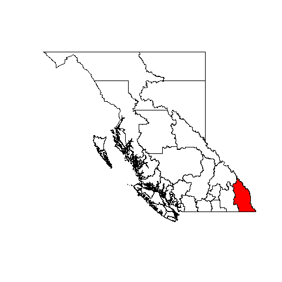

# Data Manipulation

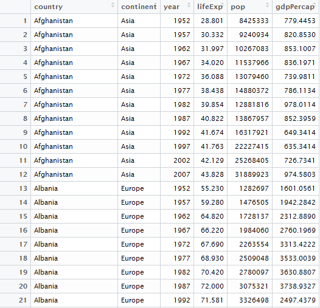

# Data Manipulation

```r
lifeData <- gapminder %>% filter(year == 2007) %>%
  group_by(continent) %>%
  summarise(meanLifeExp = mean(lifeExp))
```

| Continent | Life Expectancy |
| --- | --- |
| Africa | 54.81 |
| Americas | 73.61 |
| Asia | 70.73 |
| Europe | 77.65 |
| Oceania | 80.72 |

# Data visualisation

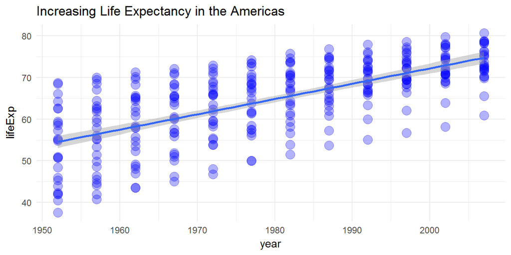

```r
ggplot(data = gapminder %>% filter(continent == "Americas"),
       aes(x=year, y=lifeExp)) +
  geom_point(alpha = 0.3, size = 4, colour = "Blue") +
  theme_minimal() +
  geom_smooth(method = 'lm') +
  labs(title = "Increasing Life Expectancy in the Americas")
```

# Resources

R can be downloaded from https://cran.r-project.org/

RStudio is available at https://www.rstudio.com/products/rstudio/download/

There are numerous resources available to learn R. http://www.cookbook-r.com/ is a useful resource with clear and concise examples of various basic tasks in R. In addition, http://stackexchange.com/ contains numerous queries and solutions that are relevant to a lot of issues a regular R user can face. In general, the vast R community online is extremely helpful in aiding new users learn the software.